# Module 01 Guided Qs

# STAT 6021: Guided Question Set 1

The data for this question is saved as bp.txt". The data set contains information on the weight (in pounds) and systolic blood pressure (in millimeters of mercury, mmHg) of 26 randomly selected males in the age group 25-30.

```r
#getwd()
data <- read.table('bp.txt', sep='\t', header = TRUE)
head(data,5)
```

|  | weight | BP |
| --- | --- | --- |
| 1 | 165 | 130 |
| 2 | 167 | 133 |
| 3 | 180 | 150 |
| 4 | 155 | 128 |
| 5 | 212 | 151 |

## Question 1

Create a scatterplot for this data set. Be sure to label the axes and give an appropriate title. Based on the appearance of the plot, does a simple linear regression appear reasonable for the data?

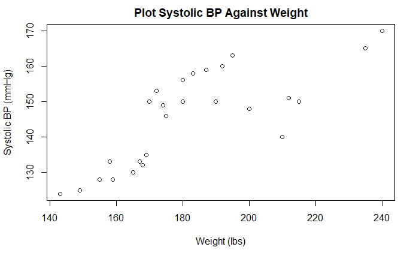

```r
attach(data)
plot(x=data$weight, y=data$BP, main='Plot Systolic BP Against Weight', xlab = 'Weight (lbs)', ylab = 'Systolic BP (mmHg)')
```

*Answer* *Yes*, it does seem reasonable that sys BP is simple linear function of weight.

## Question 2

Perform a simple linear regression for systolic blood pressure against weight. Record the estimated equation for the linear regression, and state the estimated values of the slope and intercept. Interpret the values of the estimated slope and intercept, in context.

attach(data) ##Fit a regression model

```r
lm(BP~weight)
```

```
Call:
lm(formula = BP ~ weight)

Coefficients:
(Intercept)       weight
    69.1044       0.4194
```

**Estimated simple linear regression equation** y-hat = 69.1044 + .4194(x) B0 = 69.1044 B1 = .4194

**Interpretation of slope** For every 1 lb increase of weight the model estimates a .4194 increase in systolic blood preassure, measured in mmHg.

**Interpretation of intercept** The intercept is meaningless as a weight of 0 lbs is not meaningful. A 0 lb adult male is not part of the sample or population we are analyzing.

## Question 3

For a 30-year-old male whose weight is 200, what is his predicted systolic blood pres- sure? What is his residual?

```r
yweight <- 69.1044 + (.4194 * 200)
yweight
```

```
[1] 152.9844
```

## Question 4

```r
residual <- 148 - yweight
residual
```

```
[1] -4.9844
```

Produce the ANOVA table for this linear regression.

```r
result<-lm(BP~weight)
anova(result)
```

```
Analysis of Variance Table

Response: BP
          Df Sum Sq Mean Sq F value    Pr(>F)
weight     1 2693.6 2693.58  35.744 3.591e-06 ***
Residuals 24 1808.6   75.36
---
Signif. codes:  0 ‘***’ 0.001 ‘**’ 0.01 ‘*’ 0.05 ‘.’ 0.1 ‘ ’ 1
```

```r
summary(result)
```

```
Call:
lm(formula = BP ~ weight)

Residuals:
    Min      1Q  Median      3Q     Max
-17.182  -6.485  -2.519   8.926  12.143

Coefficients:
            Estimate Std. Error t value Pr(>|t|)
(Intercept) 69.10437   12.91013   5.353 1.71e-05 ***
weight       0.41942    0.07015   5.979 3.59e-06 ***
---
Signif. codes:  0 ‘***’ 0.001 ‘**’ 0.01 ‘*’ 0.05 ‘.’ 0.1 ‘ ’ 1

Residual standard error: 8.681 on 24 degrees of freedom
Multiple R-squared:  0.5983,    Adjusted R-squared:  0.5815
F-statistic: 35.74 on 1 and 24 DF,  p-value: 3.591e-06
```

## Question 5

What is the value of R2? Explain how this value is found. What does this value mean in this context?

**Answer** The R2, Coef of determination, formula is: SS-R / SS-T, i.e. the regression error divided by the total error and can be used as a measure of how well variations in x explain variations in y.

From video 1.6 : “Strength of the linear relationship between two quantitative variables”

The closer the error explained by model is to total error, the closer the value is to 1 - which would be a model that explained 100% of the variability in y, i.e. a perfect model.

Our model has an R2 of **.5983.**

Our model, based on weight, explains roughly 60% of the variability in blood pressure.

## Question 6

What is the estimated value for the standard deviation of the error terms for this regression model, sigma-hat?

**Answer**

```r
sigma(result)
```

```
[1] 8.680852
```

## Question 7

What are the null and alternative hypotheses for the ANOVA F test?

**Answer** H0: B1 == 0 Ha: B1 != 0

## Question 8

Explain how the F statistic of 35.744 is found.

**Answer** The formula is MS-R / MS-res, or explained error divided by unexplained error.

**This is not working, what am I doing wrong??**

2693.58

1-pf(35.744,1,24)

Expected values are: E(MS-R) = sigma^2 + B1^2(Sxx) E(MS-res) = sigma^2

```r
mean(weight)
```

```
[1] 182.4231
```

```r
Sxx <- sum((weight - mean(weight))^2)
Sxx
```

```
[1] 15312.35
```

```r
sigma <- sigma(result)
sigma
```

```
[1] 8.680852
```

```r
B1 <- 69.1044

F0 <- (sigma + (B1^2 * Sxx)) / sigma
F0
```

```
[1] 8423466
```

```r
F0_fromclass = 2693.58 / 75.36
F0_fromclass
```

```
[1] 35.74283
```

```r
p_fromclass = 1-pf(35.744,1,24)
p_fromclass
```

```
[1] 3.59124e-06
```

```r
# how to find F-alpha,1,
```

## Question 9

Write an appropriate conclusion for the ANOVA F test for this simple linear regression model.

**Answer** The model is statistically significant because the F score is large. The model is a better predictor than y = B0 or Y-bar for the systolic bp of our study’s population.